# Economic Hardship Dashboard

**Offline Version — Maricopa County**

This version loads pre-built data from GitHub. No Census API key needed. All analysis is complete. Your task: write the three policy recommendations. Submit your completed .qmd and .html to Canvas.

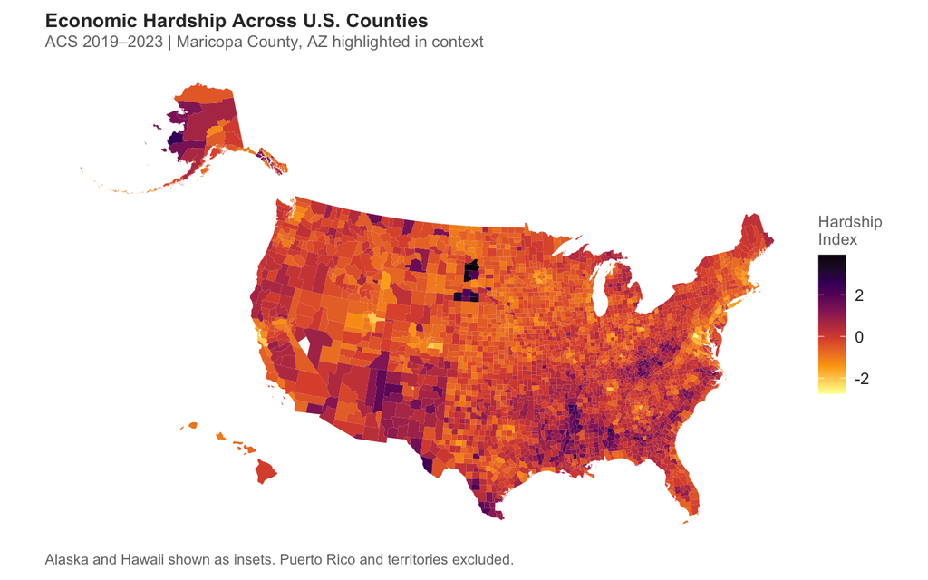

Counties Mapped

3,142

Highest Hardship County

Corson County (3.92)

Maricopa County, AZ National Rank

#2386 of 3142

| County | State | Hardship |
| --- | --- | --- |
| Corson County | South Dakota | 3.918 |
| Quitman County | Georgia | 3.691 |
| Ziebach County | South Dakota | 3.661 |
| Sioux County | North Dakota | 3.638 |
| Todd County | South Dakota | 3.45 |
| Oglala Lakota County | South Dakota | 3.149 |
| Wolfe County | Kentucky | 2.977 |
| St. Helena Parish | Louisiana | 2.902 |
| Mellette County | South Dakota | 2.79 |
| Lee County | Arkansas | 2.606 |

[output cut: 10 more lines]

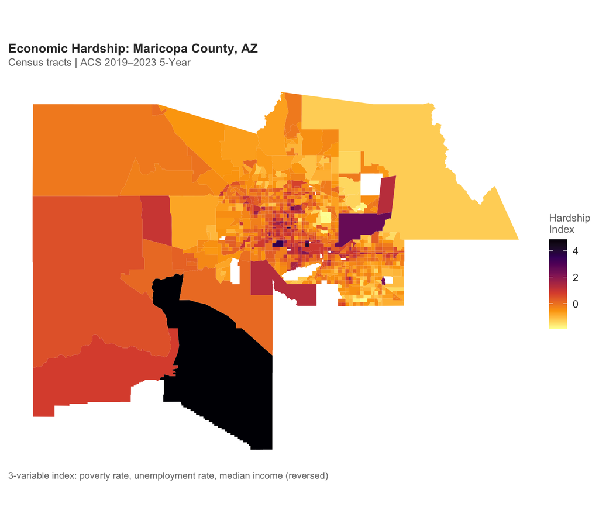

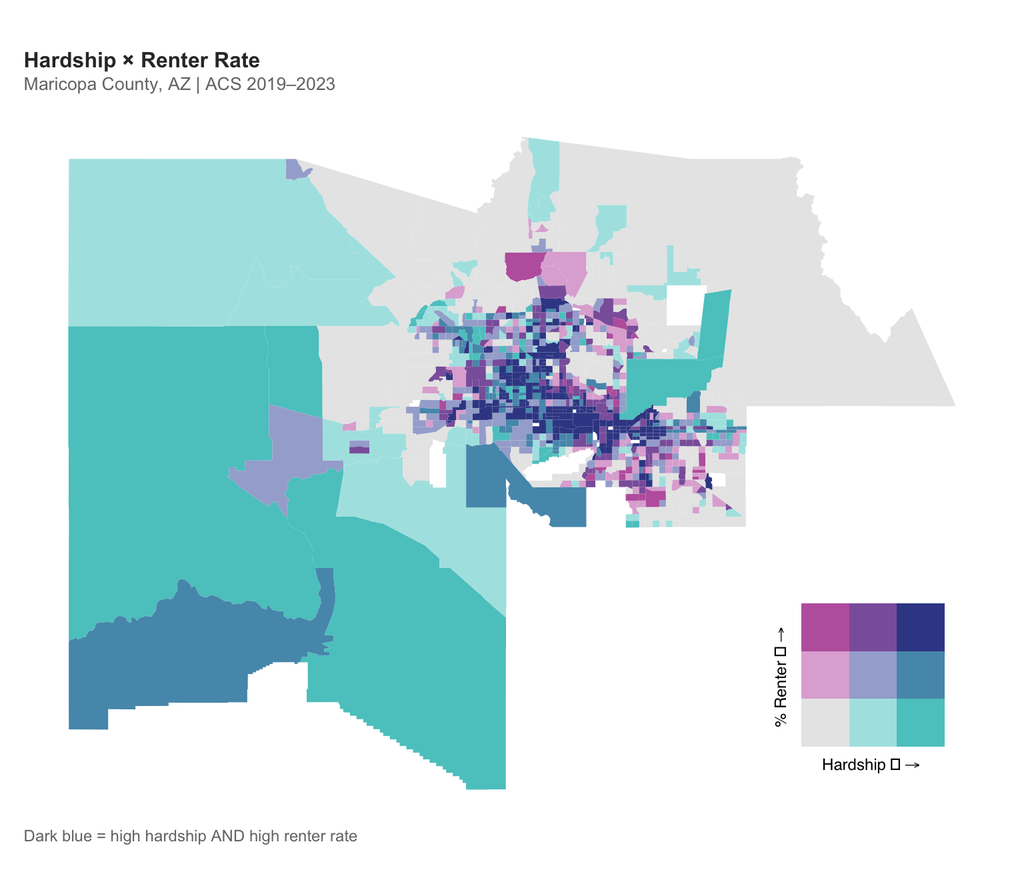

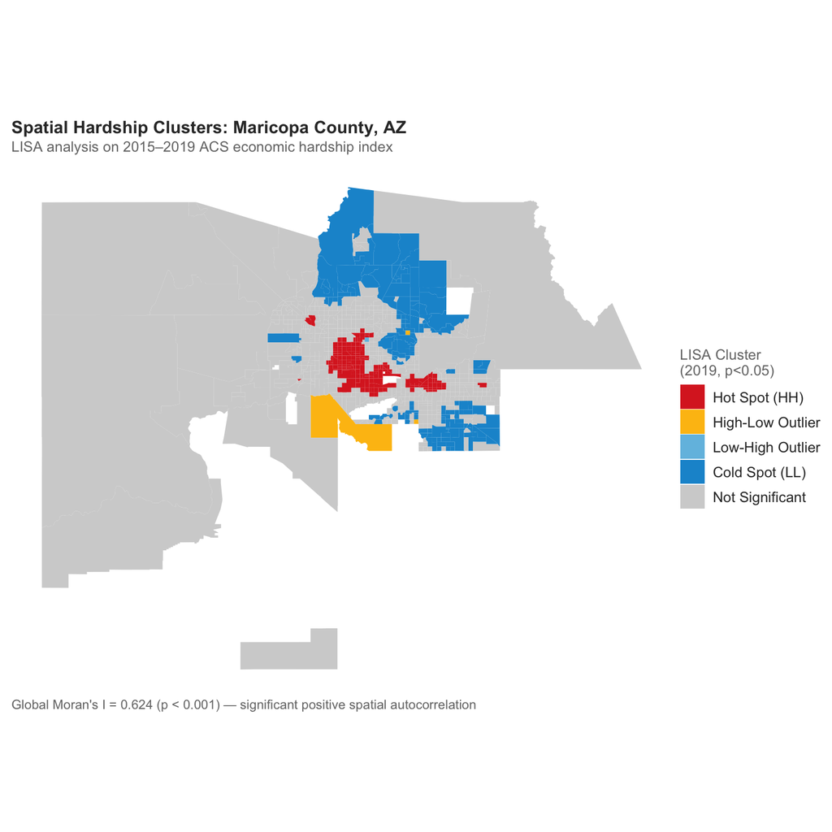

Hot Spot Tracts (HH)